# Session 05 Logistic Regression

[**CCMVI2085U Machine Learning for Predictive Analytics in Business @ CBS ISUP 2020**](https://kursuskatalog.cbs.dk/2019-2020/KAN-CCMVI2085U.aspx?lang=en-GB)

Course coordinator: [Bowei Chen](https://boweichen.github.io/) | Email: bc.acc@cbs.dk

Many business problems and decisions deal with understanding or estimating the probability associated with certain events or people's behaviors, and frequently these events or behaviors tend to be dichotomous - that is, of one type or of another type. In this session, we are going to study logistic regression, which can be used to predict the events or behaviors with binary outcomes.

# Table of Contents

## Motivating example

Suppose we are marketing analysts and working with a client company -- a credit card company which wants to advertise its credit card offer to Amazon‘s users. The company buys a dataset from Amazon. It contains some Amazon users’ recent purchase spending amounts, age and their responses (i.e., clicking) towards online advertisements. The credit card company wants to develop a prediction model to predict whether an Amazon user would be willing to click or not on its credit card banner advertisement

[figure not shown]

The first step is to load the dataset, and see some overall picture of data using descriptive analytics. In Python, we can use `pandas` library to load the dataset into Jupyter notebook and check the data variables and dimension.

```
import pandas as pd
df = pd.read_csv("data/Ad_Click.csv")
df.head()
df.shape
```

|  | Spending | Age | Click |
| --- | --- | --- | --- |
| 0 | 9.5 | 14 | 0 |
| 1 | 20.2 | 21 | 1 |
| 2 | 9.7 | 10 | 0 |
| 3 | 18.3 | 14 | 1 |
| 4 | 12.2 | 15 | 1 |

```
(200, 3)
```

We can use `matplotlib` library to draw some plots to check the distribution of each variable and the relationship between variables. Here we can also use `seaborn` library to do these checks in one pairwise plot for all variables in the dataset.

```
import numpy as np
import matplotlib.pyplot as plt
%matplotlib inline

import seaborn as sns
sns.set(font_scale=1.25)
sns.set(style="white")

# Create an instance of the PairGrid class.
g = sns.PairGrid(data= df)

def corr(x, y, **kwargs):

    # Calculate the value
    coef = np.corrcoef(x, y)[0][1]

    # Make the label
    label = r'$\rho$ = ' + str(round(coef, 2))

    # Add the label to the plot
    ax = plt.gca()
    ax.annotate(label, xy = (0.2, 0.95), size = 16, xycoords = ax.transAxes)

def hide_current_axis(*args, **kwds):
    plt.gca().set_visible(False)

# Map the plots to the locations
g.map_lower(plt.scatter)
g.map_lower(corr)
g.map_upper(hide_current_axis)
g.map_diag(plt.hist, bins = 10, edgecolor =  'k');
```

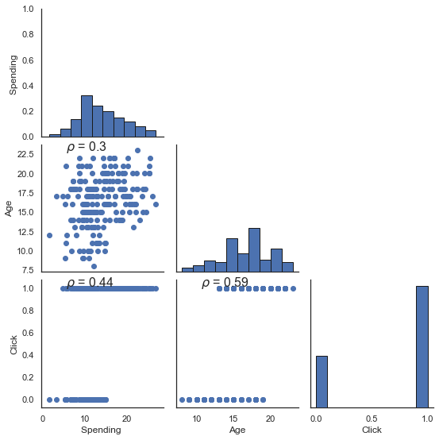

## Logistic regression

In the following, we are going to develop a logistic regression model to predict whether a new advertisement will be clicked or not when we are given the values of `Spending` and `Age`.

### Mathematical setting of data

Let's set up the mathematical notations at the beginning. We denote the dataset $\mathcal{D}$, where

$$\mathcal{D} = \{(\boldsymbol{x}_1, y_1), \cdots, (\boldsymbol{x}_N, y_N)\} = \{(\boldsymbol{x}_n, y_n)\}_{n=1}^{N}$$$$ \boldsymbol{X} = \left[ \begin{array}{ccc} x_{11} & \cdots & x_{1D} \\ \vdots & \ddots & \vdots \\ x_{N1} & \cdots & x_{ND} \\ \end{array} \right] = \left[ \begin{array}{c} \boldsymbol{x}_1^\top \\ \vdots\\ \boldsymbol{x}_N^\top \\ \end{array} \right] , \ \ \ \ \ \boldsymbol{y} = \left[ \begin{array}{ccc} y_{1} \\ \vdots \\ y_{N} \\ \end{array} \right]$$

In logistic regression, we employ the linear form to represent the contributions/effects of variables towards the response prediction. Specifically, each variable has a weight and the total contribution of variables is the linear combination of variables' values and their weights. Similar to multiple linear regression, we often absorb the bias term $w_0$ into the weight vector for multiple logistic regression $$ \boldsymbol{w} = \left[ \begin{array}{c} w_0\\ w_1 \\ \vdots\\ w_D \\ \end{array} \right] $$

The input matrix and vectors are adjusted as follows: $$ \boldsymbol{X} = \left[ \begin{array}{cccc} 1 & x_{11} & \cdots & x_{1D} \\ \vdots & \vdots & \ddots & \vdots \\ 1 & x_{N1} & \cdots & x_{ND} \\ \end{array} \right] = \left[ \begin{array}{c} \boldsymbol{x}_1^\top \\ \vdots\\ \boldsymbol{x}_N^\top \\ \end{array} \right], $$ where $\boldsymbol{x}_1^\top = [1, x_{11}, \ldots, x_{1D}]$

### Logistic/sigmoid function

We use the logistic function (also called sigmoid function) to convert the total contribution of variables/features into probability which shows how likely the event or behavior will occur. The following is the mathematical definition of logistic regression and how does it look like in terms of domain and co-domain.

For any $x \in \mathbb{R}$, the logistic/sigmoid function $f(x)$ is defined as $$f(x) = \frac{e^{x}}{1+ e^{x}},$$ therefore, $f(x) \in [0,1]$

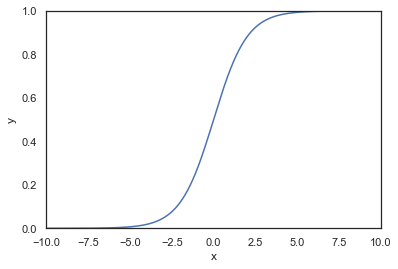

In logistic regression, the total contribution of variables/features for the $n$th sample is defined by

$$z_n = \boldsymbol{w}^\top \boldsymbol{x}_n.$$

The probability of the sample to be clicked can be estimated by the logistic function as follows

$$p_n = \mathbb{P}(y_n=1 | \boldsymbol{x}_n) =\frac{e^{z_n}}{1+ e^{z_n}}.$$

In other words, once the weight vector $\boldsymbol{w}$ is determined, we can obtain the logistic regression for predicting future transactions.

### Estimating the weights

There are two major ways to estimate the weights of logistic regression: maximum likelihood and cross-entropy.

#### Maximum likelihood

Since \begin{align*} p_n = & \ \mathbb{P}(y=1 | \boldsymbol{x}_n) = \frac{e^{\boldsymbol{w}^\top \boldsymbol{x}_n}}{1+ e^{\boldsymbol{w}^\top \boldsymbol{x}_n}},\\ 1- p_n = & \ \mathbb{P}(y=0 | \boldsymbol{x}_n) = \frac{1}{1+ e^{\boldsymbol{w}^\top \boldsymbol{x}_n}}. \end{align*}

The likelihood of $\boldsymbol{w}$ is given \begin{align*} \mathscr{L}(\boldsymbol{w}) & = \mathbb{P}(\boldsymbol{y} | \boldsymbol{w}, \boldsymbol{X}) \\ & = \prod_{n=1}^{N} \mathbb{P}(y_n | \boldsymbol{w}, \boldsymbol{x}_n) \\ & = \prod_{n=1}^{N} p_n^{y_n} \big(1- p_n \big)^{1-y_n}. \end{align*}

The optimal $\boldsymbol{w}^*$ can be obtained by maximizing $\mathscr{L}(\boldsymbol{w}) $. However, directly calculating $\mathscr{L}(\boldsymbol{w})$ is computationally difficult, instead, we can obtain $\boldsymbol{w}^*$ by maximizing log-likelihood $\log\{\mathscr{L}(\boldsymbol{w})\}$.

The log-likelihood of $\boldsymbol{w}$ is given

\begin{align*} \text{LL}(\boldsymbol{w}) & = \log \{ \mathscr{L}(\boldsymbol{w}) \} \\ & = \log \bigg\{ \prod_{n=1}^{N} p_n^{y_n} \big(1- p_n \big)^{1-y_n} \bigg\} \\ & = \sum_{n=1}^{N} \bigg[ y_n \log \big\{ p_n \big\} + (1 - y_n) \log \big\{ 1 - p_n \big\} \bigg] \\ & = \sum_{n=1}^{N} \bigg[ y_n \boldsymbol{w}^\top \boldsymbol{x}_n - \log \Big\{ (1 + \boldsymbol{w}^\top \boldsymbol{x}_n \Big\} \bigg] \end{align*}

Therefore, the optimal $\boldsymbol{w}^*$ can be obtained by $$ \text{max} \ \text{LL}(\boldsymbol{w}) $$

#### Cross-entropy

Cross entropy is a measure from information theory, which shows the distance between two probability distributions $p$ and $q$ over the same underlying set of events. $$ H(p,q) = - \mathbb{E}_p[\log q] = - \sum_x p(x) \log\{q(x) \}. $$

In machine learning, cross-entropy is often used as the loss function to evaluate the performance of a classification model whose output is a probability between 0 and 1. For logistic regression, the cross-entropy loss function can be defined as follows:

\begin{align*} \text{EN}(\boldsymbol{w}) & = H(\boldsymbol{y}, \boldsymbol{p}) = - \sum_{n=1}^{N} \bigg[ y_n \log \big\{ p_n \big\} + (1 - y_n) \log \big\{ 1 - p_n \big\} \bigg] \end{align*}

Therefore, the optimal $\boldsymbol{w}^*$ can be obtained by

$$ \text{min} \ \text{EN}(\boldsymbol{w}) $$

#### Equivalence of log-likelihood and cross-entropy as loss

For logistic regression, maximizing the log-likelihood is equivalent to minimizing the negative log-likelihood (NLL), and is equivalent to minimizing the cross entropy:

$$ \text{max} \ \text{LL}(\boldsymbol{w}) \Leftrightarrow \text{min} \ \text{NLL}(\boldsymbol{w}) \Leftrightarrow \text{min} \ \text{EN}(\boldsymbol{w}) $$

The difference between likelihood and cross-entropy is that the former represents a structured and principled statistical approach to modeling while the latter represents performance based training (because machine learning models aim to achieve good performance at the tasks which people are interested).

The discussion can be extended to the multiclass case by using the multinoulli likelihood and the softmax cross-entropy.

#### Newton's method

We know that we can obtain the optimal weights of logistic regression by maximizing the log-likelihood or minimizing the cross-entropy, so we just need to solve this optimization problem! There are several methods can be used. Here we study Newton's method.

We can simply write Newton's method in terms of algorithm as follows

1: **Choose** initial guess of the root $x_0$  
2: **Update** the guess of the root $x_{i} = x_{i-1} - \frac{f(x_{i-1})}{f^\prime(x_{i-1} )}$, where $i$ is the index starting from 1.  
3: **Update** the value of function $y_{i} = f(x_{i})$.  
4: **Repeat** steps 2 and 3 until $y_{i} - y_{i-1} \approx 0$.  
5: **Return** the root $x_i$

In optimization, Newton's method is applied to the derivative $f^\prime(x)$ of a twice-differentiable function $f(x)$ to find the roots of the derivative, which are the solutions to equation $f^\prime(x) = 0$, also known as the stationary points of $f(x)$. These solutions may be minima, maxima, or saddle points.

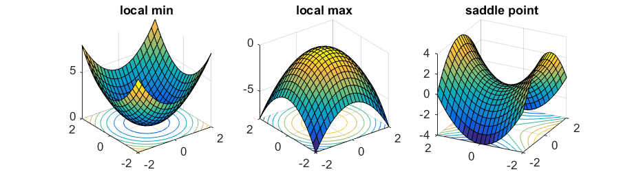

In logistic regression, let's consider the log likelihood function $\text{LL}(\boldsymbol{w})$. The maxima of $\text{LL}(\boldsymbol{w})$ correspond to points where its first derivative $\nabla \text{LL}(\boldsymbol{w})=0$. Therefore, we can have the following algorithm for the estimation of $\boldsymbol{w}$.

1: **Choose** initial guess of $\boldsymbol{w}_0$
2: **Update** the guess $$\boldsymbol{w}_{i} = \boldsymbol{w}_{i-1} - \boldsymbol{H}^{-1} \nabla_{\boldsymbol{w}} \text{LL}(\boldsymbol{w}_{i-1}),$$ where $i$ is the index starting from 1, $\nabla_{\boldsymbol{w}} \text{LL}(\boldsymbol{w}_{i-1})$ is the derivative of $\text{LL}(\boldsymbol{w}_{i-1})$ with respect to $\boldsymbol{w}_{i-1}$, and $\boldsymbol{H}^{-1}$ is the inverse of Hessian matrix.
3: **Update** the value of function $y_{i} = \text{LL}(\boldsymbol{w}_{i})$.
4: **Repeat** steps 2 and 3 until $y_{i} - y_{i-1} \approx 0$.
5: **Return** the root $\boldsymbol{w}_{i}$

"Newton’s method typically enjoys faster convergence than (batch) gradient descent, and requires many fewer iterations to get very close to the minimum. One iteration of Newton’s can, however, be more expensive than one iteration of gradient descent, since it requires finding and inverting an $n$-by-$n$ Hessian; but so long as n is not too large, it is usually much faster overall. When Newton’s method is applied to maximize the logistic regression log likelihood function $\text{LL}(\boldsymbol{w})$, the resulting method is also called Fisher scoring."  
-- Andrew Ng, Stanford CS229 Machine Learning Notes

#### sklearn to solve the optimization for logistic regression

In `sklearn`, the class `sklearn.linear_model.LogisticRegression` provides the following solvers

{‘newton-cg’, ‘lbfgs’, ‘liblinear’, ‘sag’, ‘saga’}, default=’lbfgs’

Algorithm to use in the optimization problem.

For small datasets, ‘liblinear’ is a good choice, whereas ‘sag’ and ‘saga’ are faster for large ones.

For multiclass problems, only ‘newton-cg’, ‘sag’, ‘saga’ and ‘lbfgs’ handle multinomial loss; ‘liblinear’ is limited to one-versus-rest schemes.

‘newton-cg’, ‘lbfgs’, ‘sag’ and ‘saga’ handle L2 or no penalty

‘liblinear’ and ‘saga’ also handle L1 penalty

‘saga’ also supports ‘elasticnet’ penalty

‘liblinear’ does not support setting penalty='none'

https://scikit-learn.org/stable/modules/generated/sklearn.linear_model.LogisticRegression.html

### Train logistic regression in sklearn

We want to use `sklearn` library to train/develop a logistic regression model. The first step is to convert the loaded data into ndarray of `numpy`

```
x = df.iloc[:, :-1].to_numpy()
y = df.iloc[:, -1].to_numpy()
```

Let's then randomly split the dataset into 70% training and 30% test

```
from sklearn.model_selection import train_test_split
x_train, x_test, y_train, y_test = train_test_split(x, y, test_size=0.3, random_state=0)
```

The training and test sets of data after splitting can be visualised as follows:

[interactive chart not shown]

Now let's train/develop a logistic regression model using the training set

```
from sklearn.linear_model import LogisticRegression
clf = LogisticRegression(random_state=0, solver="liblinear")
clf.fit(x_train, y_train)
```

Note that the solver in optimization can be replaced with other candidates, such as ‘newton-cg’, ‘lbfgs’, ‘liblinear’, ‘sag’, ‘saga’

Let's take a look at what does the trained logistic regression look like.

[interactive chart not shown]

## Classification model evaluation metrics

There are many metrics to evaluate if a trained machine learning model is good or not. Logistic regression is a classification model and in today's session we study logistic regression for binary outcomes (i.e., two classes), so let's look at the evaluation metrics for two-class classification model here.

Firstly, Let's look at the predictions made by the model for the training data set

```
y_prob_train = clf.predict_proba(x_train)[:, 1]
y_pred_train = clf.predict(x_train)
df_result_training = pd.DataFrame([y_train, y_prob_train, y_pred_train])
df_result_training = df_result_training.T
df_result_training.columns = ["Label_GT", "Label_Prob", "Label_Pred"]
df_result_training.head(10)
```

|  | Label_GT | Label_Prob | Label_Pred |
| --- | --- | --- | --- |
| 0 | 0.0 | 0.725493 | 1.0 |
| 1 | 1.0 | 0.824724 | 1.0 |
| 2 | 1.0 | 0.926160 | 1.0 |
| 3 | 0.0 | 0.388772 | 0.0 |
| 4 | 1.0 | 0.759101 | 1.0 |
| 5 | 1.0 | 0.975112 | 1.0 |
| 6 | 1.0 | 0.871541 | 1.0 |
| 7 | 1.0 | 0.787572 | 1.0 |
| 8 | 1.0 | 0.823509 | 1.0 |
| 9 | 1.0 | 0.914796 | 1.0 |

We can further investigate the model predictions against actual data. Here in machine learning terminology we call them **ground truth**.

```
prob_click = df_result_training.loc[df_result_training["Label_GT"] == 1, "Label_Prob"]
prob_noclick = df_result_training.loc[df_result_training["Label_GT"] == 0, "Label_Prob"]


plt.figure(figsize=[15, 5])

plt.subplot(1, 2, 1)

plt.hist(prob_click.values, bins=15, alpha=0.75, label="Click")
plt.hist(prob_noclick.values, bins=15, alpha=0.75, label="No click")
plt.legend(loc="upper right")
plt.xlabel("$p$")
plt.ylabel("Frequency")


plt.subplot(1, 2, 2)

sns.distplot(prob_click.values, hist=False, bins=15, label="Click")
sns.distplot(prob_noclick.values, hist=False, bins=15, label="No click")
plt.axvline(x=0.5, ymin=0, ymax=4, color="g", label="Threshold/decision boundary")
plt.xlabel("$p$")
plt.ylabel("Frequency")
plt.legend(loc="upper right")

plt.show()
```

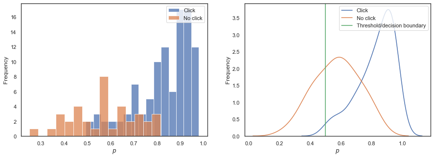

### Confusion matrix

Based on our threshold/decision boundary, we can evaluate how many positive and negative samples are correctly predicted/classified by the trained logistic regression. **Remember, so far we are looking at the training data.**

The following is the so-called **confusion matrix**, where

- **True positive (TP)** represents the model predicts positive and its prediction is correct. Here in our example positive means click.
- **True negative (TN)** represents the model predicts negative and its prediction is correct. Here in our example negative means no click.
- **False positive (FP)** represents the model predicts positive but its prediction is incorrect.
- **False negative (FN)** represents the model predicts negative and its prediction is incorrect.

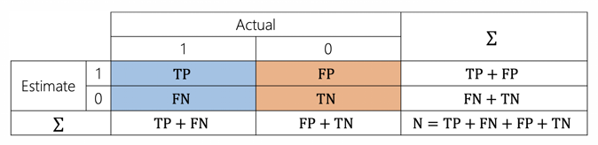

We can quickly calculate the TP, TN, FP, FN:

```
tp = df_result_training[(df_result_training["Label_Pred"]==1) & (df_result_training["Label_GT"]==1)].shape[0]
tn = df_result_training[(df_result_training["Label_Pred"]==0) & (df_result_training["Label_GT"]==0)].shape[0]
fp = df_result_training[(df_result_training["Label_Pred"]==1) & (df_result_training["Label_GT"]==0)].shape[0]
fn = df_result_training[(df_result_training["Label_Pred"]==0) & (df_result_training["Label_GT"]==1)].shape[0]
```

Alternatively, we can use the function from `sklearn` to calculate confusion matrix and use `seaborn` to visualize it

```
from sklearn.metrics import confusion_matrix

cf_matrix = confusion_matrix(y_train, y_pred_train)

group_names = ["TN", "FP", "FN", "TP"]
group_counts = ["{0:0.0f}".format(value) for value in cf_matrix.flatten()]
group_percentages = [
    "{0:.2%}".format(value) for value in cf_matrix.flatten() / np.sum(cf_matrix)]
labels = [f"{v1}\n{v2}\n{v3}" for v1, v2, v3 in zip(group_names, group_counts, group_percentages)]
labels = np.asarray(labels).reshape(2, 2)

fig=plt.figure()
sns.heatmap(cf_matrix, annot=labels, fmt="", cmap="Blues")
plt.show()
```

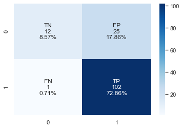

Let's see how TP, TN, FP, FN are obtained based on our threshold/decision boundary.

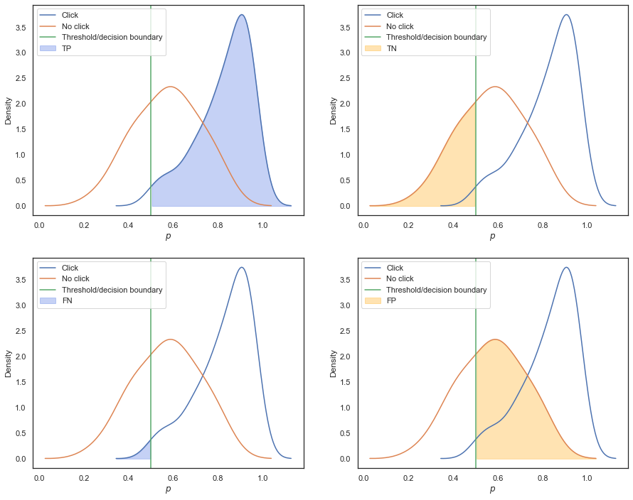

### Accuracy, recall, precision and F1 score

Based on confusion matrix, we can define the following evaluation metrics:

- **Accuracy** is the most intuitive performance measure and it is simply a ratio of correctly predicted observation to the total observations.

\begin{align*} \text{Accuracy} & \ = \frac{\text{TP} + \text{TN}}{\text{FP} + \text{FN} + \text{TP} + \text{TN}} \\ \text{Error Rate} & \ = \frac{\text{FP} + \text{FN}}{\text{FP} + \text{FN} + \text{TP} + \text{TN}} = 1 - \text{Accuracy} \\ \end{align*}

- **Precision** is the ratio of correctly predicted positive observations to the total predicted positive observations. The question that this metric answer is of all advertisements that are predicted to be clicked, how many actually are clicked?

\begin{align*} \text{Precision} & \ = \frac{\text{TP}}{\text{TP} + \text{FP}} \end{align*}

- **Recall or true positive rate (TPR)** is the ratio of correctly predicted positive observations to the all observations in actual class. The question recall answers is that that of all the advertisements that are truly clicked, how many did we predict?

\begin{align*} \text{True Positive Rate (TPR)} & \ = \text{Recall} = \frac{\text{TP}}{\text{TP} + \text{FN}}\\ \text{False Positive Rate (FPR)} & \ = \frac{\text{FP}}{\text{FP} + \text{TN}} \end{align*}

- **F1 score** is the weighted average of precision and recall. Therefore, this score takes both false positives and false negatives into account. Intuitively it is not as easy to understand as accuracy, but F1 is usually more useful than accuracy, especially if you have an uneven class distribution. Accuracy works best if false positives and false negatives have similar cost. If the cost of false positives and false negatives are very different, it’s better to look at both Precision and Recall.

\begin{align*} \text{F1 Score} & \ = \frac{2 \times \text{Recall} \times \text{Precision}}{\text{Recall} + \text{Precision}} \end{align*}

In Python, we can use `sklearn` to calculate the above evaluation metrics

```
from sklearn.metrics import classification_report
print(classification_report(y_train, y_pred_train))
```

```
              precision    recall  f1-score   support

           0       0.92      0.32      0.48        37
           1       0.80      0.99      0.89       103

    accuracy                           0.81       140
   macro avg       0.86      0.66      0.68       140
weighted avg       0.83      0.81      0.78       140
```

### Receiver operator characteristic (ROC) curve

The ROC curve illustrates the true positive rate (TPR) against false positive rate (FPR) of our model. We are hoping the ROC curve will hug the upper left corner of our graph. A classifier with 50-50 accuracy is deemed 'worthless'; this is no better then random guessing, as in the case of a coin flip.

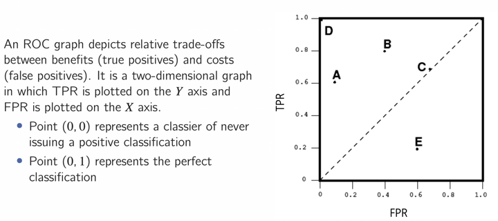

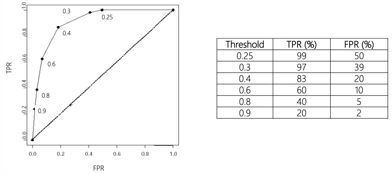

The **area under the ROC curve** (simply AUC) gives a numerical measure between 0 and 1 for model's classification performance

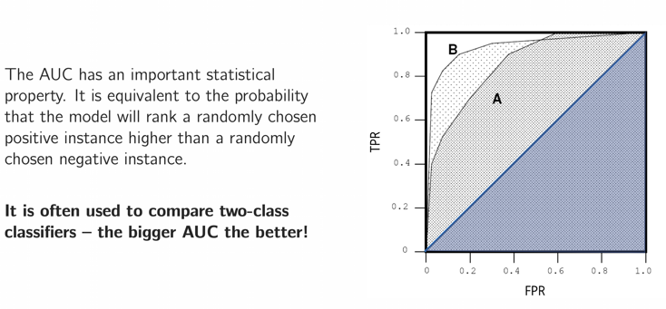

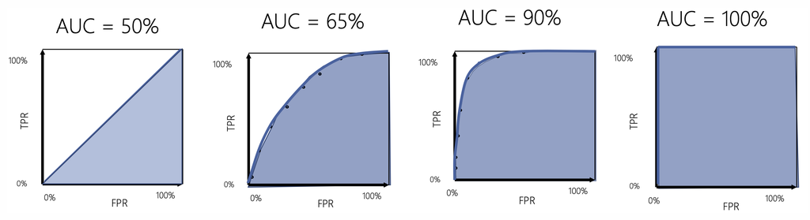

The following toy example show when the trained model can perfectly predict positive and negative samples, the AUC is equal 1.

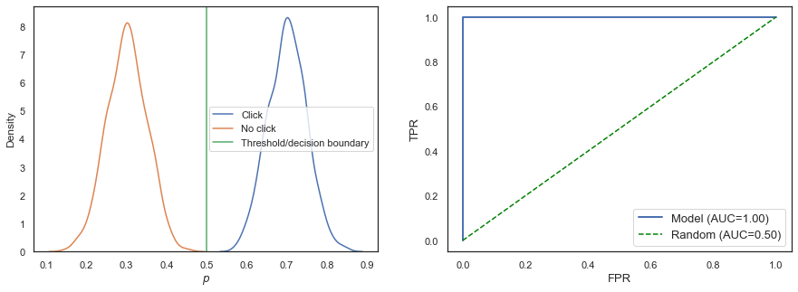

The following toy example show when the trained model's performance is poor, almost similar to random guess like we flip a fair coin, so its AUC is equal 0.5.

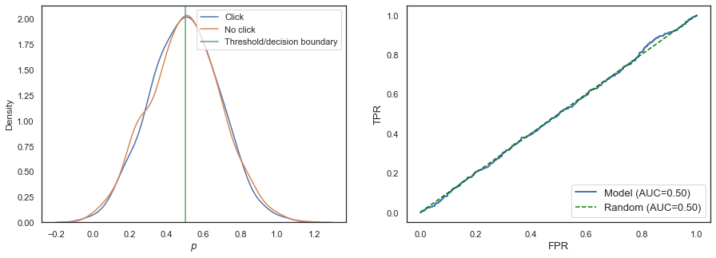

We can use `sklearn` library to calculate ROC and AUC, and then plot ROC diagram for the logistic regression model.

```
from sklearn.metrics import roc_curve, auc

fpr, tpr, thresholds = roc_curve(y_train, y_prob_train)
roc_auc = auc(fpr, tpr)

plt.figure(figsize=[7, 6])
plt.plot(
    fpr, tpr, label="Logistic regression (AUC={:0.2f})".format(roc_auc), linewidth=2
)
plt.plot([0, 1], [0, 1], color="green", linestyle="--", label="Random (AUC=0.50)")
plt.xlabel("FPR", fontsize=13)
plt.ylabel("TPR", fontsize=13)
plt.legend(loc="lower right", fontsize=13)
plt.show()
```

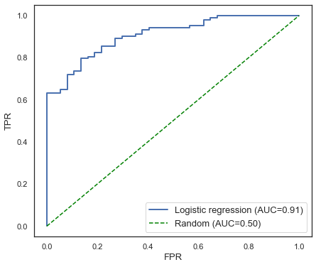

So far we have evaluated the logistic regression model with the training data. Same evaluation operations can be applied to the test data set. I will leave this as an exercise for workshop practice.